# PA1_template1

Jose Carlos

August 2, 2020

## What is mean total number of steps taken per day?

# Histogram

```r
newdata <- summarize(group_by(data, date), sum(steps))
```

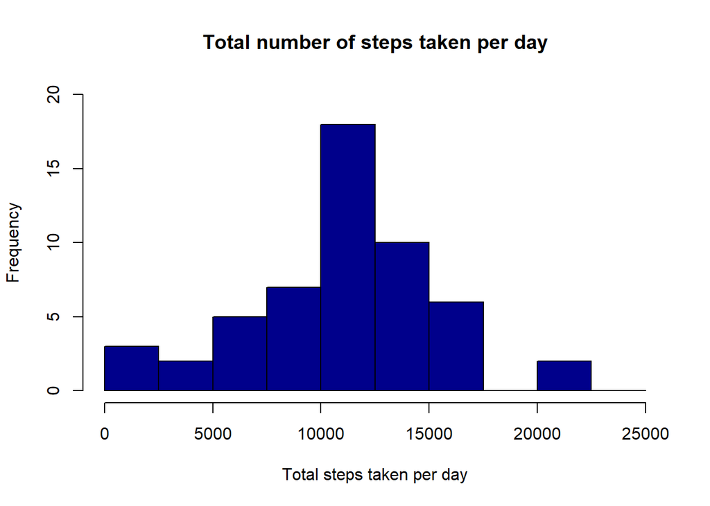

```r
names(newdata) <- c("date", "steps")
newdata <- na.omit(newdata)
hist(newdata$steps, main = "Total number of steps taken per day", xlab = "Total steps taken per day",
     col = "darkblue", ylim = c(0,20), breaks = seq(0,25000, by=2500))
```

# Mean and median

```r
mean(newdata$steps)
```

```
## [1] 10766.19
```

```r
median(newdata$steps)
```

```
## [1] 10765
```

## What is the average daily activity pattern?

# Make a time series plot of the 5-minute interval and the average number of steps taken, averaged across all days

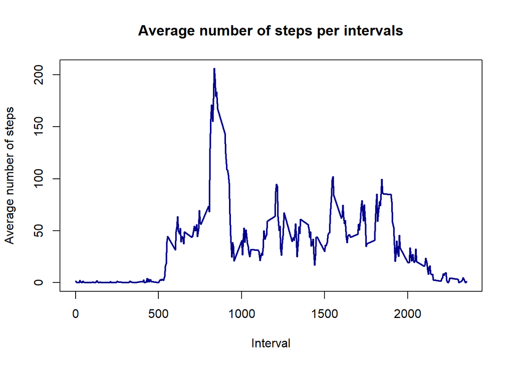

```r
intervaldata <- aggregate(activity$steps, by=list(activity$interval), FUN=mean, na.rm=TRUE)
names(intervaldata) <- c("interval", "mean")
plot(intervaldata$interval, intervaldata$mean, type = "l", col="darkblue", lwd = 2,
     xlab="Interval", ylab="Average number of steps", main="Average number of steps per intervals")
```

# Which 5-minute interval, on average across all the days in the dataset, contains the maximum number of steps?

```r
intervaldata[which.max(intervaldata$mean), ]$interval
```

```
## [1] 835
```

# Calculate and report the total number of missing values in the dataset

```r
sum(is.na(data))
```

```
## [1] 2304
```

# Devise a strategy for filling in all of the missing values in the dataset.

```r
imputed_steps <- intervaldata$mean[match(data$interval, intervaldata$interval)]
```

# Create a new dataset that is equal to the original dataset but with the missing data filled in.

```r
imputed_steps <- intervaldata$mean[match(data$interval, intervaldata$interval)]
```

# Create a new dataset that is equal to the original dataset but with the missing data filled in.

```r
activity_imputed <- transform(activity, steps = ifelse(is.na(activity$steps),
                                                       yes = imputed_steps, no = activity$steps))
total_imputed <- aggregate(steps ~ date, activity_imputed, sum)
names(total_imputed) <- c("date", "daily_steps")
```

# Make a histogram of the total number of steps taken each day and Calculate and report the mean and median total number of steps taken per day.

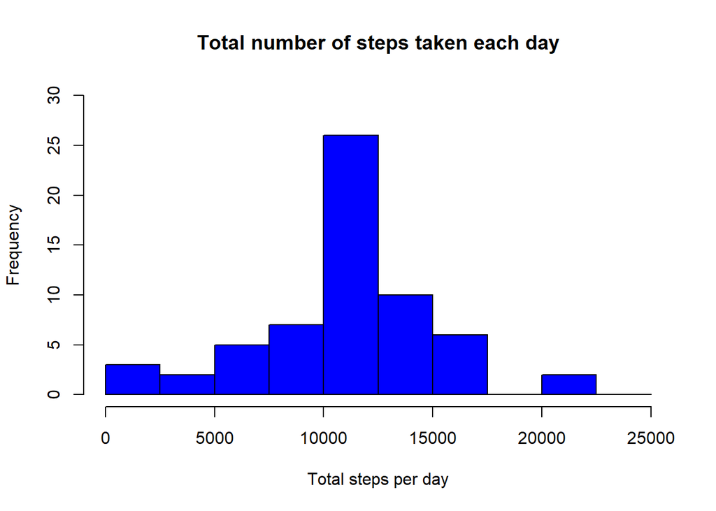

```r
hist(total_imputed$daily_steps, col = "blue", xlab = "Total steps per day", ylim = c(0,30),
     main = "Total number of steps taken each day", breaks = seq(0,25000,by=2500))
```

# mean and median

```r
mean(total_imputed$daily_steps)
```

```
## [1] 10766.19
```

```r
median(total_imputed$daily_steps)
```

```
## [1] 10766.19
```

## Are there differences in activity patterns between weekdays and weekends?

# Create a new factor variable in the dataset with two levels: “weekday” and “weekend” indicating whether a given date is a weekday or weekend day.

```r
data$date <- as.Date(strptime(activity$date, format="%Y-%m-%d"))
data$datetype <- sapply(data$date, function(x) {
        if (weekdays(x) == "Saturday" | weekdays(x) =="Sunday")
        {y <- "Weekend"} else
        {y <- "Weekday"}
        y
})
```

# Make a panel plot containing a time series plot of the 5-minute interval and the average number of steps taken, averaged across all weekday days or weekend days.

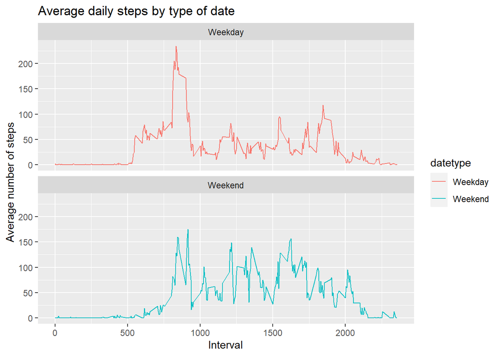

```r
activitydate <- aggregate(steps~interval + datetype, data, mean, na.rm = TRUE)
plot <- ggplot(activitydate, aes(x = interval , y = steps, color = datetype)) +
        geom_line() +
        labs(title = "Average daily steps by type of date", x = "Interval", y = "Average number of steps") +
        facet_wrap(~datetype, ncol = 1, nrow=2)
print(plot)
```